# League Of Legends Data Exploration - Gold Edition

Selwyn Davis

April 3, 2017

Hi there! Once again my name is Selwyn and I’m here to do a little analysis on data from the NA LCS. Last time I focused around [Kills, Deaths and Assists](https://cdn.rawgit.com/Selwyn-Davis/League-of-Legends-Data-Exploration/b7d93ecb/League_of_Legends_Data_Exploration-KDA.html) and this time I’m going to focus around, as you may have guessed from the title, Gold. We’re gonna start with taking a look at mean Gold Earned per Minute(GpM) for each role.

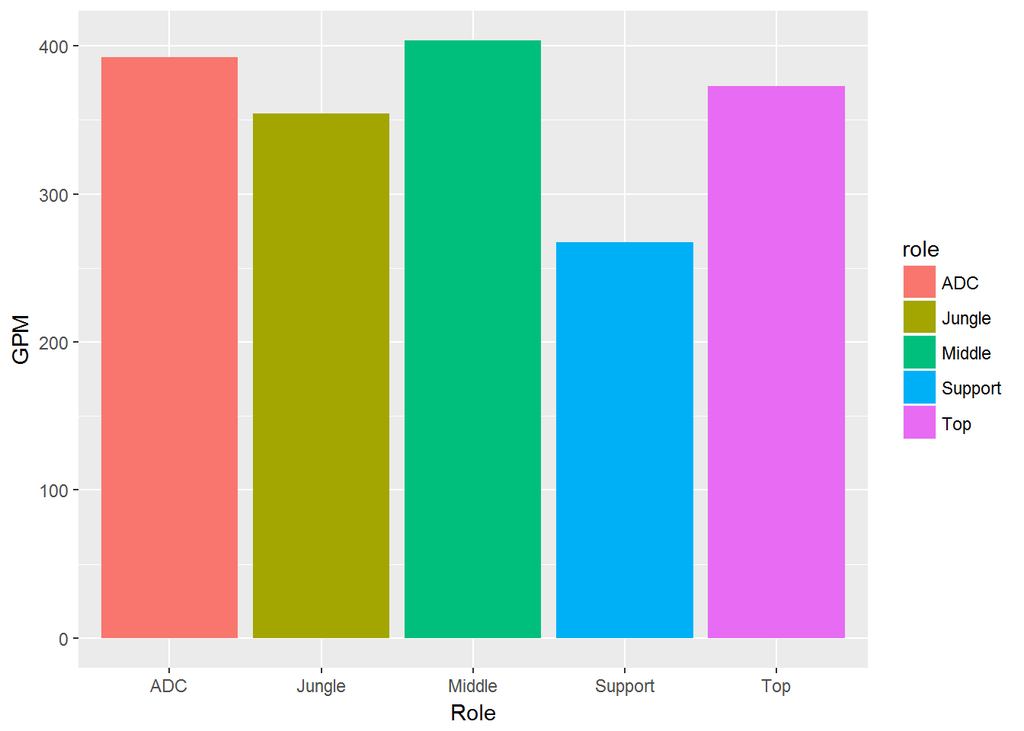

We can tell immediately that Mid Laners and ADC’s are alloted the most gold on their team, followed by Top Laners, Junglers and SUpports in last place. This is to be expected due to the structure of the game so nothing too enlightening here. It’ll be more interesting to look at each role’s gold allocation in wins compared to losses.

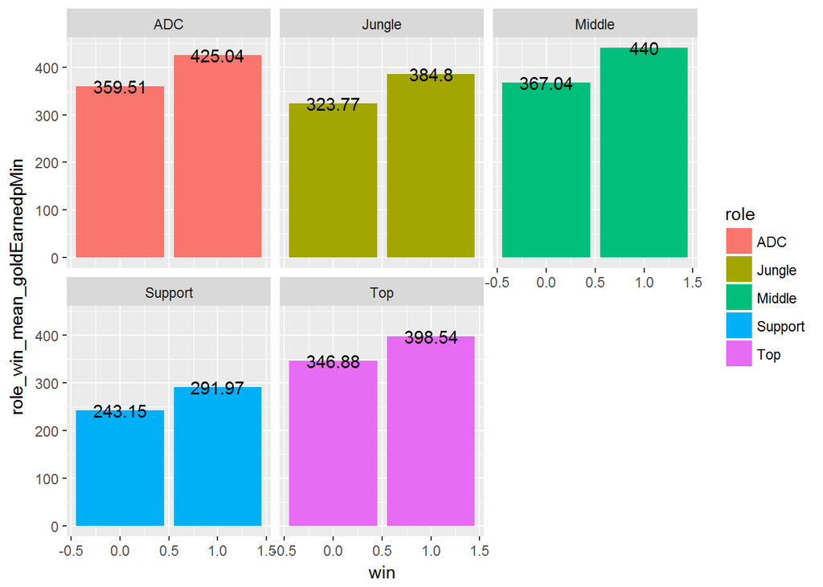

As we can see the biggest variation between the average GPM in wins versus losses is in the mid lane. It’ll be interesting to look at the some of the individual match ups in this regard. Lo and behold, we actually have a stat at our fingertips that does exactly that. Let’s take a look at the mean endgame gold difference between players and their exact match ups. We’ll do it by role to since it makes the most sense.

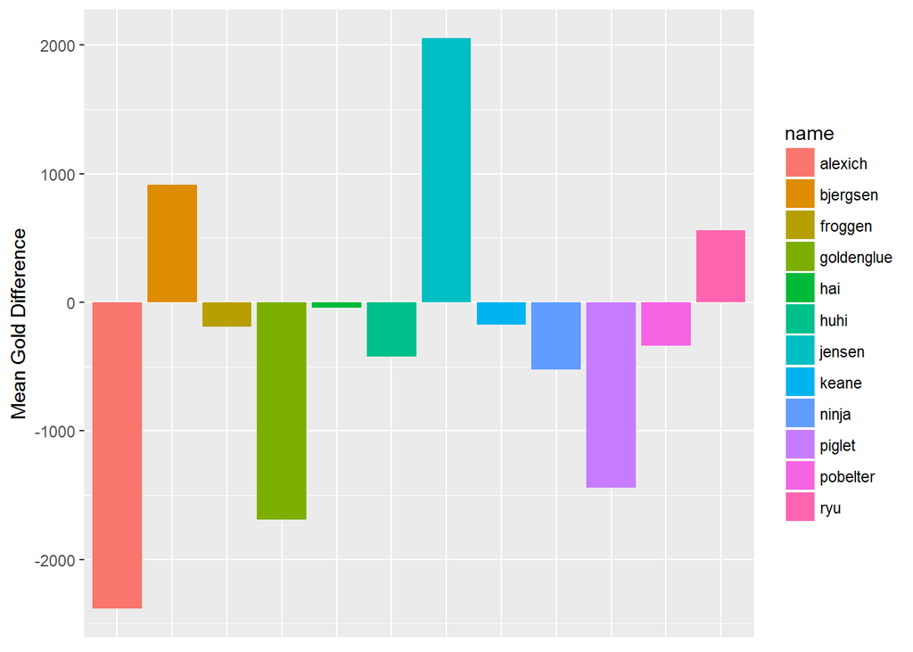

The most notable piece of information to take away from this is that Jensen is a monster in the mid lane. The closest mid laner in terms of average gold difference is Bjergsen and Jensen averages about 2.3 times the gold lead that he does. There are only three mid laners that even come up positive in this regard. These players rack up large leads when they’re ahead and manage to keep their gold differential small when they’re behind. Looking at this stat could also help us pick out power players for each team.

1. Jensen 2053.70455 — (1.98995141)
2. Bjergsen 914.44681 — (1.02922283)
3. Ryu 560.17073 — (0.73046413)
4. Hai -41.30233 — (0.22324585)
5. Keane -175.38636 — (0.11017366)
6. Froggen -192.16279 — (0.09602621)
7. Pobelter -337.56818 — (-0.02659321)
8. Huhi -424.47727 — (-0.09988307)
9. Ninja -520.34146 — (-0.18072472)
10. Piglet -1442.80952 — (-0.95863599)
11. Goldenglue -1687.42308 — (-1.16491699)
12. AlexIch -2379.25000 — (-1.74833010)

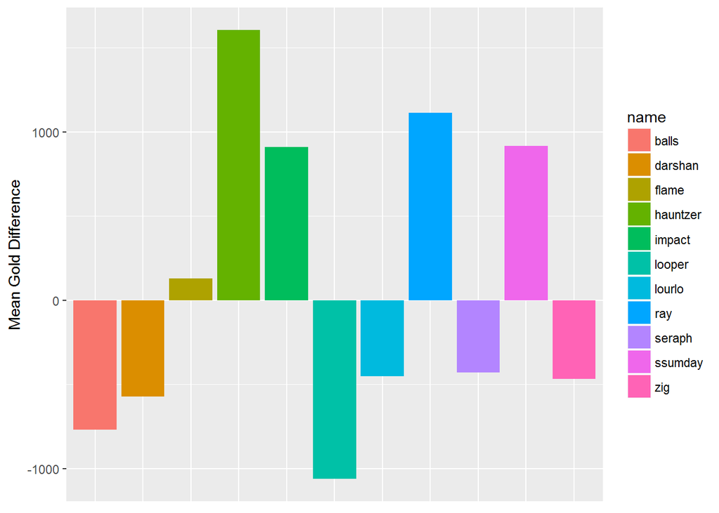

With a lot less variation and more players coming up positive in gold difference Top lane is more tightly distributed. However we can see that Hauntzer stands above the competition quite convincingly. Ssumday is known to be the beneficiary of top centric gameplay throughout the season and we can see that it has pushed him into the 3rd spot despite a losing team record. I would be worried about the match up between Hauntzer and Balls during the quarterfinals because if previous performance is any indicator we have quite the opportunity for some explosive action.

1. Hauntzer 1605.8085 — (1.69361073)
2. Ray 1113.8000 — (1.14602582)
3. Ssumday 915.4091 — (0.92522503)
4. Impact 909.6471 — (0.91881213)
5. Flame 129.2500 — (0.05026283)
6. Seraph -428.5556 — (-0.57055144)
7. Lourlo -451.1277 — (-0.59567325)
8. Zig -466.9024 — (-0.61322992)
9. Darshan -571.7273 — (-0.72989557)
10. Balls -770.4651 — (-0.95108249)
11. Looper -1060.1628 — (-1.27350389)

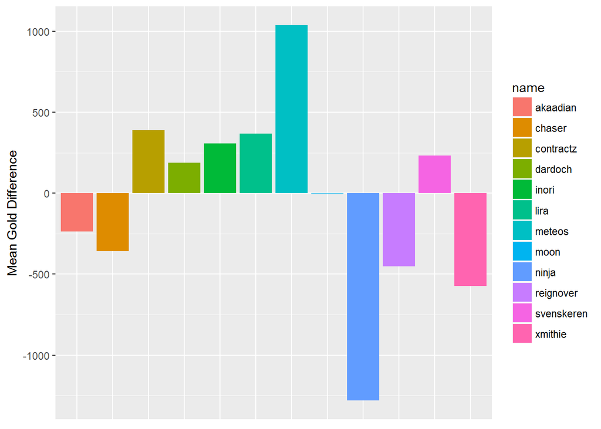

And in the jungle role We have Dark Meteos reigning supreme. Important to note that similiar to many of the other outliers on these lists Meteos has fewer games than most. Unlike the other substitutes that have played this split Meteos finds himself on the top, outperforming resident LCS junglers during his short stint. Another interesting fact is that in the jungle role is where TSM finds their weakest performer in gold advantage. Most of the highest ranking players in this statistc are from teams from the highest win rate. Obvious to say the least, but deviations are important to notice. Lira for instance is on the team with the lowest winrate, but manages to average golds leads over enemy junglers.

1. Meteos 1037.421053 — (1.79915321)
2. Contractz 389.022727 — (0.70836906)
3. Lira 366.804878 — (0.67099253)
4. Inori 307.000000 — (0.5703842)
5. Svenskeren 230.914894 — (0.44238824)
6. Dardoch 189.181818 — (0.37218174)
7. Moon -3.581395 — (0.04790104)
8. Akaadian -237.465116 — (-0.34555564)
9. Chaser -359.568182 — (-0.55096655)
10. Reignover -452.872340 — (-0.70792978)
11. Xmithie -573.022727 — (-0.91005575)
12. Ninja -1278.500000 — (-2.09686237)

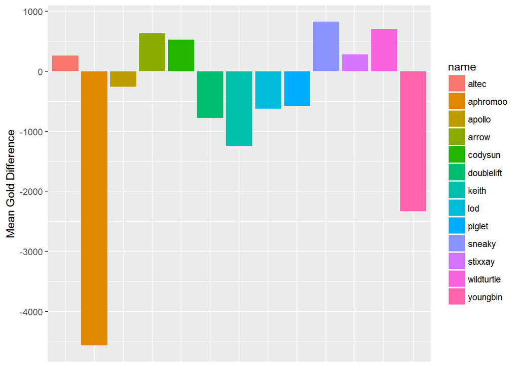

In the ADC role the top half of the rankings are much tighter. Sneaky does make his presence felt at the top, but he’s not so far away from his peers as Jensen or Hauntzer is. We do learn that Aphromoo is gonna need a bit more practice before he can challenge Stixxay for the ADC position on CLG. CodySun has performed quite well in his role despite his team’s difficulties. Deserving of a pat on the back at the very least.

1. Sneaky 828.0000 — (0.91208018)
2. Wildturtle 708.1702 — (0.83265982)
3. Arrow 638.5366 — (0.78650829)
4. Codysun 526.9773 — (0.71256940)
5. Stixxay 283.6190 — (0.5512773)
6. Altec 263.9767 — (0.53825884)
7. Apollo -258.4889 — (0.19198091)
8. Piglet -580.6154 — (-0.02151695)
9. LOD -621.8409 — (-0.04884025)
10. Doublelift -775.4000 — (-0.15061561)
11. Keith -1244.5581 — (-0.46156258)
12. Youngbin -2330.3333 — (-1.18118882)
13. Aphromoo -4564.0000 — (-2.66161052)

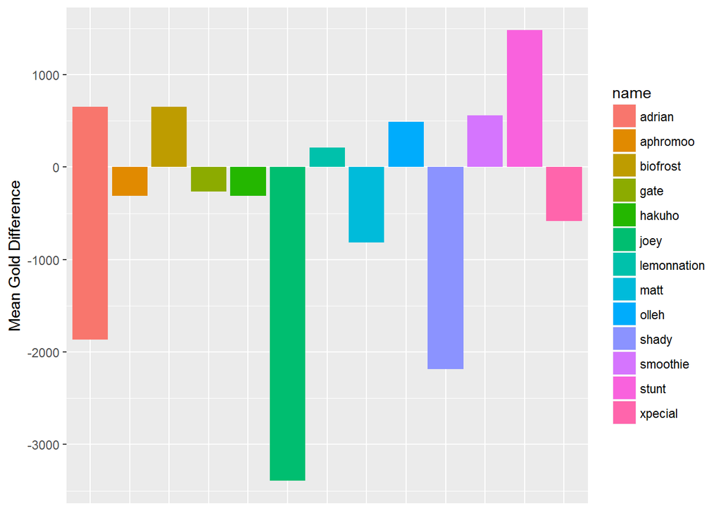

### As a Bonus(Because I love bonuses even when you don’t ask) I thought it might be interesting to take a look at the gold percentages of each team and see if we can find a difference.

(Just a note I thought it was best to remove support from this visual because it won’t likely tell you much abouts the manner in which a team’s resources are distributed since there isn’t a strategy that takes into account support’s gold share in order to win.)

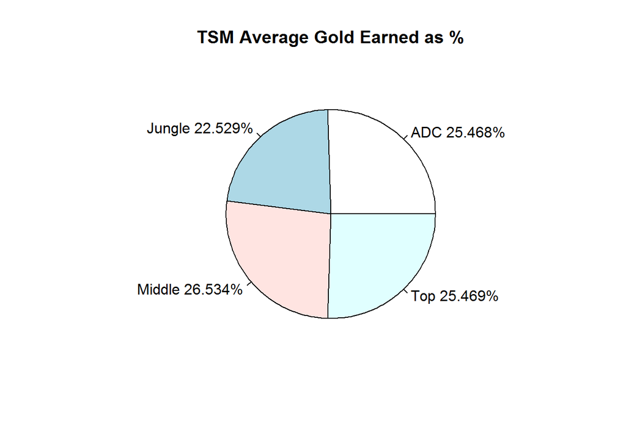

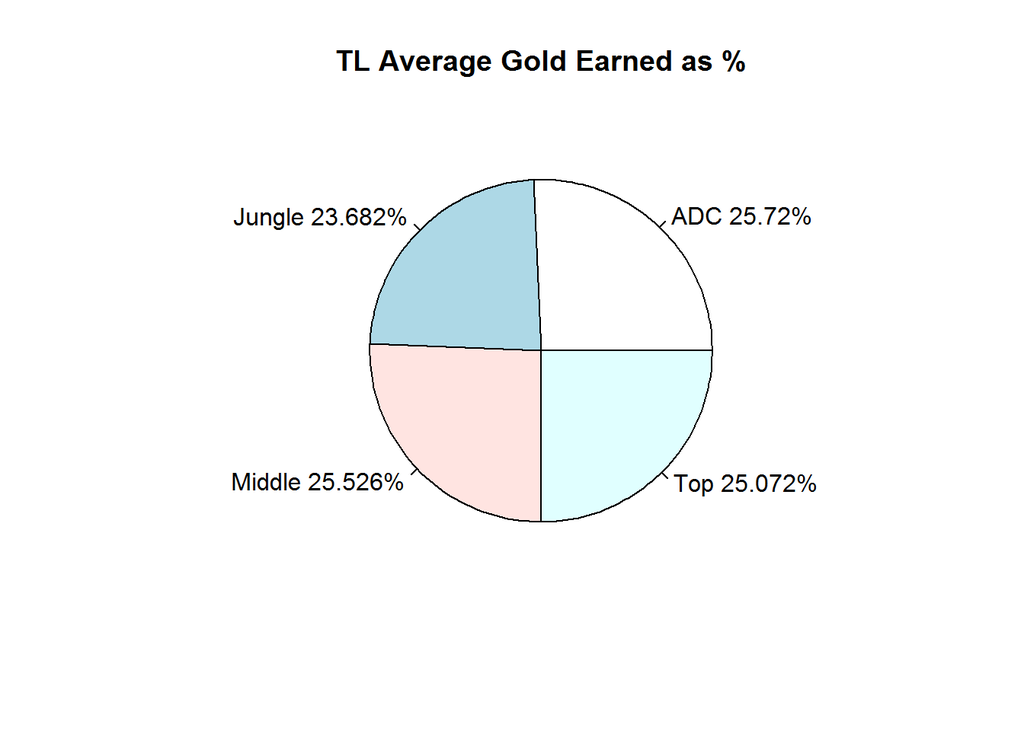

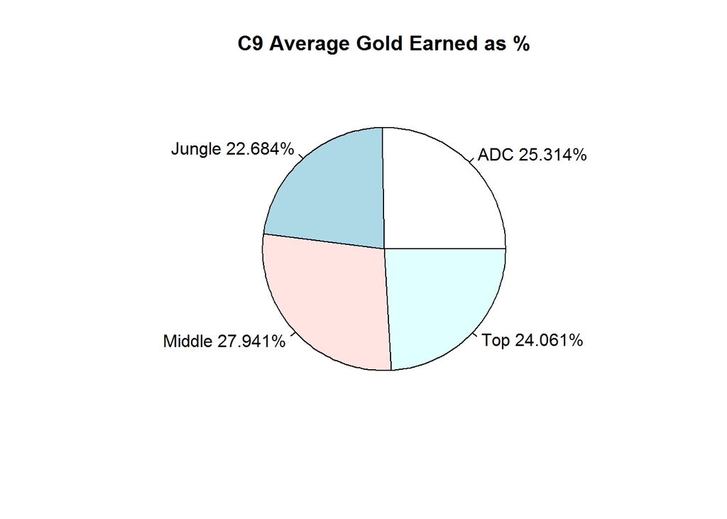

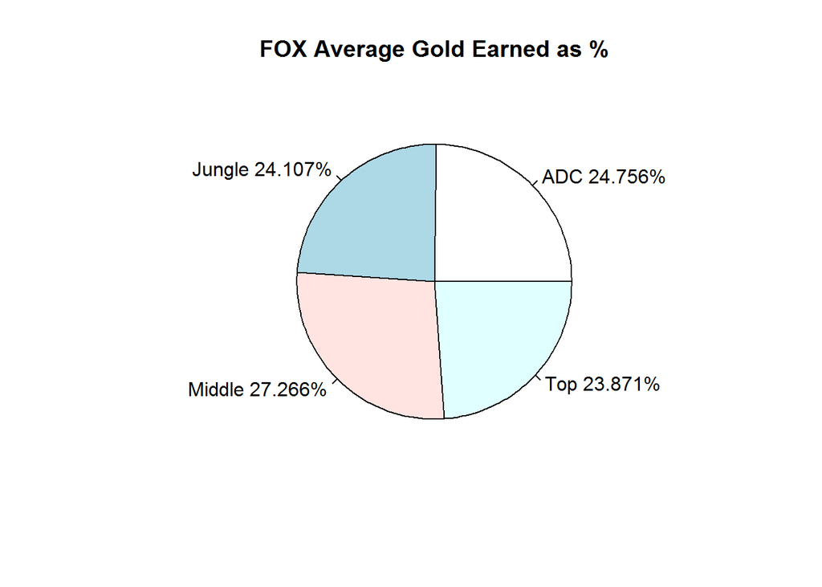

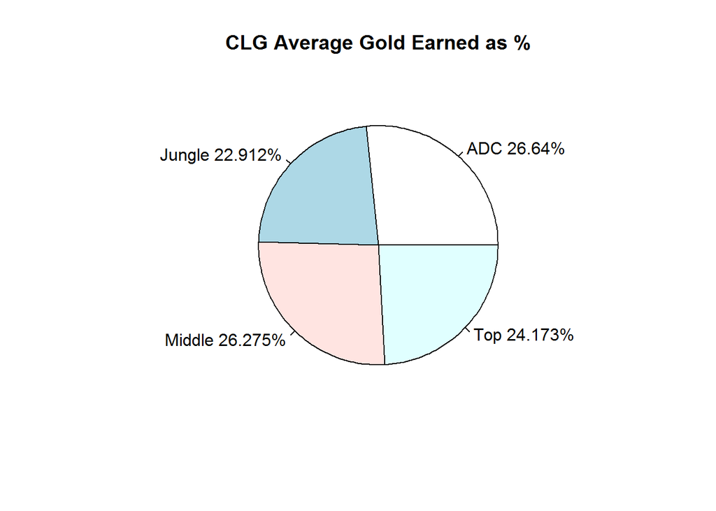

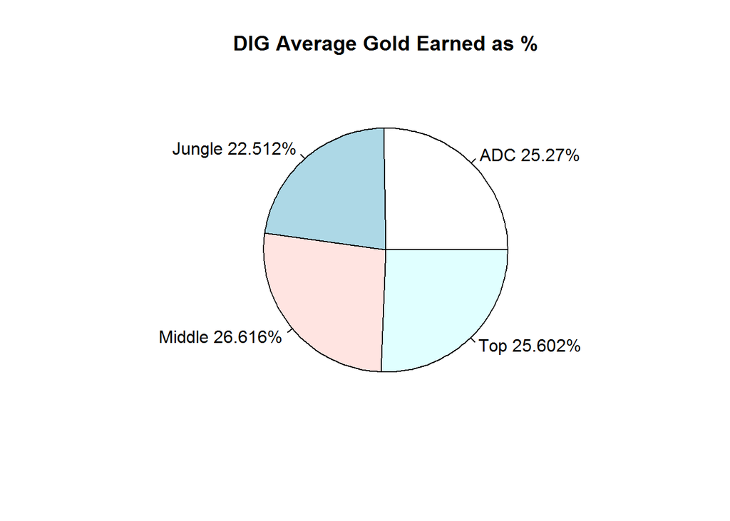

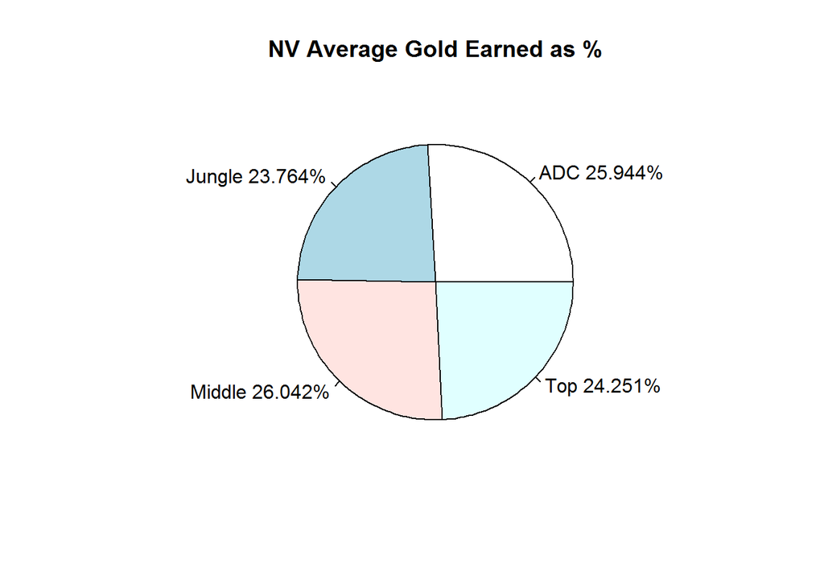

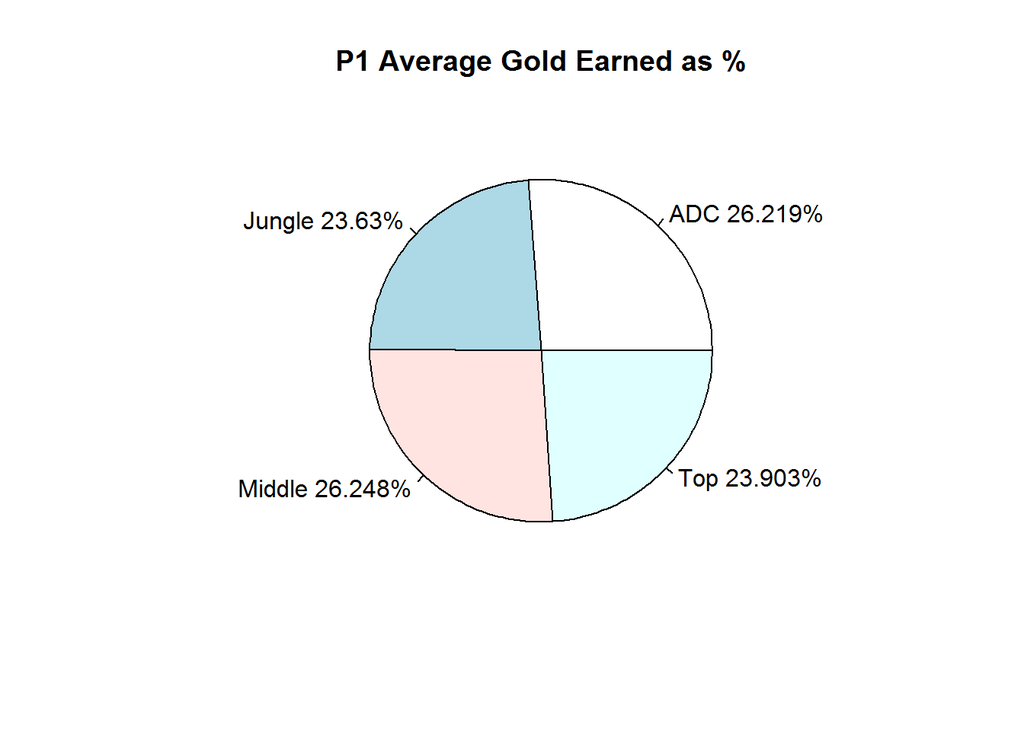

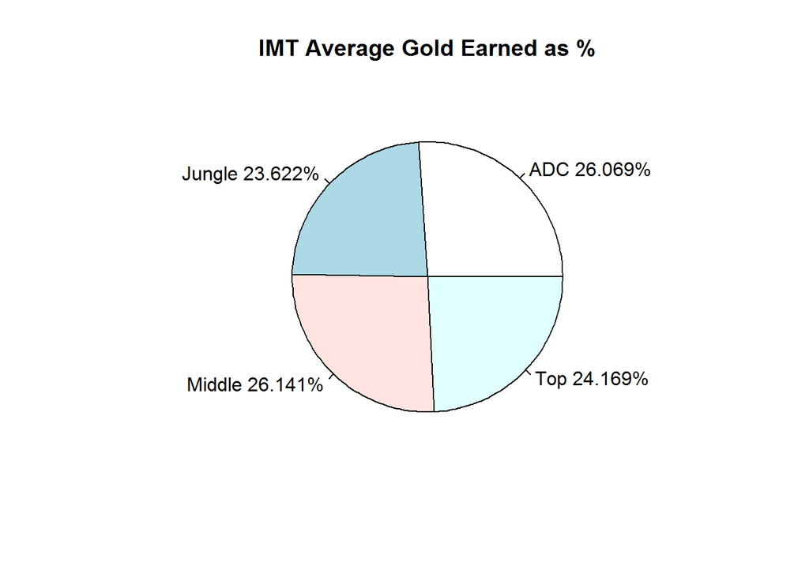

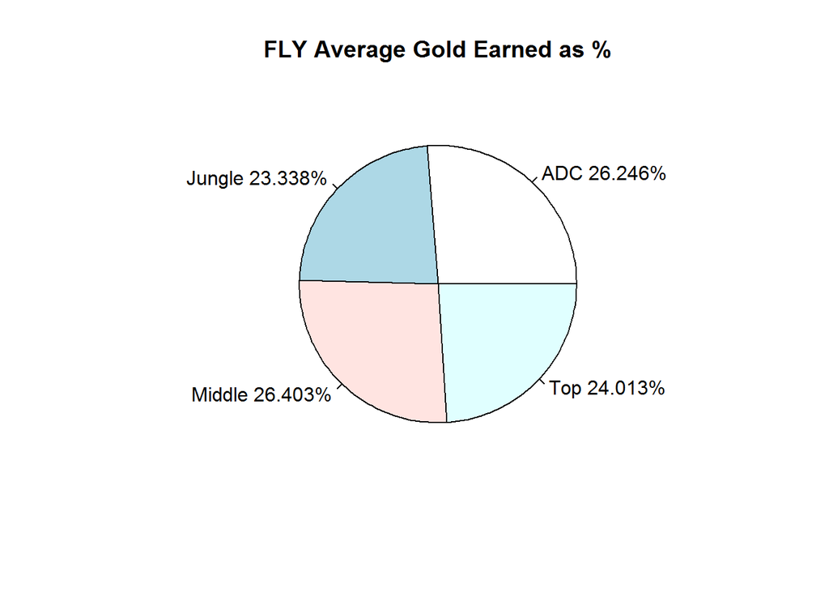